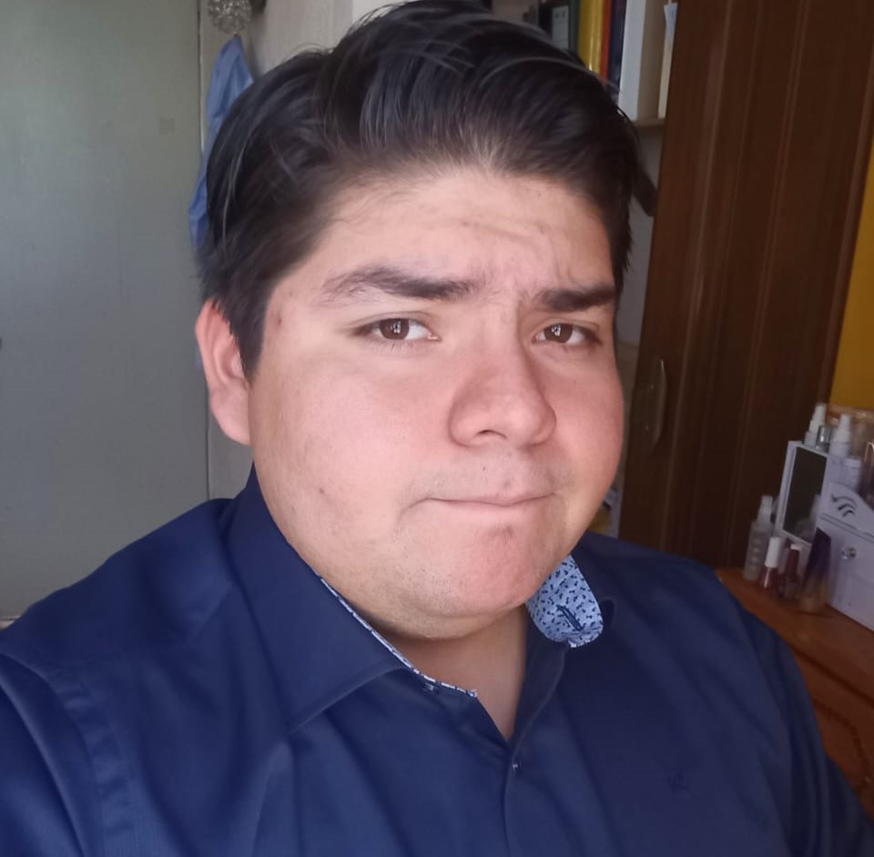

# A. Román Zamora López

Undergraduate student in Genomic Sciences at UNAM, with a multidisciplinary interest in bioinformatics and data analysis.

## Academic Background

Undergraduate Student in Genomic Sciences - National Autonomous University of Mexico

## Research Experience

Six months of training in a research laboratory focused on gene regulatory networks, with experience in applied bioinformatics.

## Technical Skills

Programming: Python (main), R, C, Bash

Data Analysis: Genome assembly, massive sequencing analysis

Infrastructure & Tools: Server management, databases, Git/GitHub, BLAST, etc.

Artificial Intelligence: Applications in bioinformatics

### Languages

Spanish: Native

English: Fluent (B2 level, certification in progress)

## About me

### Values and Personality

- Loyal, hardworking, dedicated, and committed.
- Patient, calm, kind, and diplomatic.
- Respectful, tolerant, and open to new ideas.
- Values sincerity and harmony within a group.

### Work Skills

- Meticulous, reliable, and precise in task execution.
- Analytical and systematic in decision-making.
- Ability to follow procedures and minimize risks.
- Strong teamwork and collaboration skills to achieve common goals.

### Preferences and Motivations

- Prefers stable, peaceful, and organized environments.
- Motivated by belonging to a group or organization.
- Avoids confrontations and conflict situations.

### Areas for Improvement

- Can be overly patient and compassionate with others.
- Feels stressed under pressure or in conflicts, sometimes becoming indecisive.
- Tends to yield in discussions to avoid confrontations.